# AM-Spotify

Juan Pablo Vallejo

# Caso Spotify

## Analisis Exploratorio de los Datos

### Columnas

```r
dataset <- read.csv("dataset.csv",header=TRUE)

colnames(dataset)
```

```
##  [1] "X"                        "cancion_nombre"
##  [3] "cancion_popularidad"      "cancion_artista"
##  [5] "cancion_artista_completo" "cancion_album"
##  [7] "cancion_numero"           "pais_nombre"
##  [9] "feature_bailabilidad"     "feature_energia"
## [11] "feature_clave"            "feature_fuerza"
## [13] "feature_modo"             "feature_hablado"
## [15] "feature_acustico"         "feature_instrumental"
## [17] "feature_en_vivo"          "feature_positividad"
## [19] "feature_tempo"            "feature_duracion_ms"
## [21] "feature_tiempo_compas"    "album_fecha"
```

### Descripcion de las variables

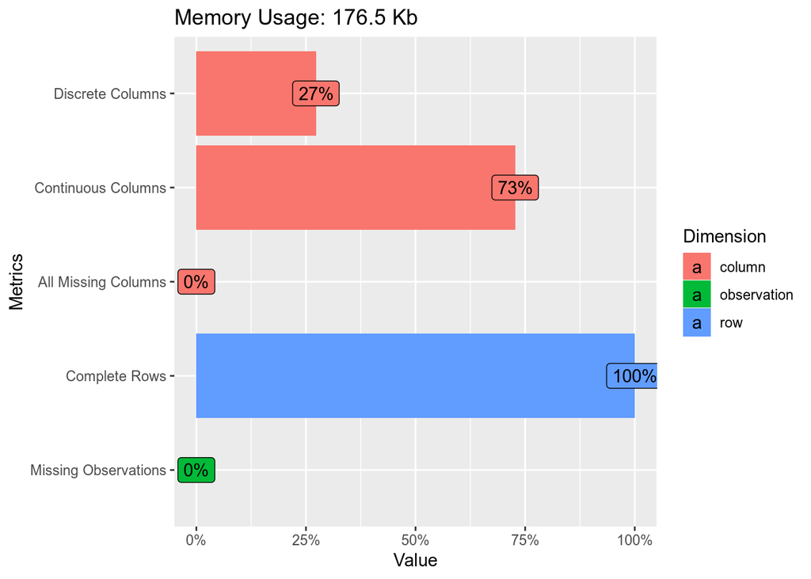

```r
plot_intro(dataset)
```

### Variables

```r
variables <- read.csv("variables.csv",header=TRUE)
kable( variables[,], caption = 'Variables') %>%
  kable_styling(bootstrap_options = c("striped", "hover", "condensed", "responsive"))
```

Variables

| Variable | Clase | Descripcion |
| --- | --- | --- |
| cancion | caracter | Nombre de la canción |
| popularidad | numerica | Popularidad en la plataforma |
| artista | caracter | Nombre del/la artista |
| artista_completo | caracter | Nombre completo del/la artista |
| album | caracter | Nombre del álbum |
| top_pais | caracter | País del ranking ‘El Top 50 de …’ |
| puesto | entera | Puesto que ocupa en este ranking |
| bailabilidad | numerica | Calidad de bailable (de 0 -> 1) |
| energia | numerica | Intensidad y actividad (de 0 -> 1); ej: heavy metal cercano a 1 |
| tonalidad | factor | Tonalidad: 0 = Do; 1 = C#; 2 = Re y así sucesivamente |
| volumen | numerica | Volumen promedio en decibeles |
| modo | factor | Modo: Mayor/Menor |
| hablado | numerica | Detecta la presencia de palabra hablada (0->1) ej: un podcast tendría puntaje alto |
| acustico | numerica | Detecta si es acústica (0->1) |
| instrumental | numerica | Instrumental (0->1); más de 0.5 es considerado instrumental |
| en_vivo | numerica | Público presente (0->1); ej: un recital debería tener valor cercano a 1 |
| positividad | numerica | Positividad (0->1) valores cercanos a 1 son alegres; eufóricos; y valores cercanos a 0 son tristes o de ira |
| tempo | numerica | Tempo promedio (pulsos/minuto) |
| duracion | numerica | Duración en milisegundos |
| tiempo_compas | entera | Cantidad de pulsos por compás |
| fecha | caracter | Fecha de lanzamiento |

### Tipos de datos:

```r
str(dataset)
```

```
## 'data.frame':    902 obs. of  22 variables:
##  $ X                       : int  1 2 3 4 5 6 7 8 9 10 ...
##  $ cancion_nombre          : Factor w/ 226 levels "¿Quien Tu Eres?",..: 34 95 8 28 39 174 181 64 24 219 ...
##  $ cancion_popularidad     : int  91 37 86 42 95 46 89 85 87 39 ...
##  $ cancion_artista         : Factor w/ 126 levels "6ix9ine","A-SHO",..: 101 89 100 120 34 60 11 88 98 60 ...
##  $ cancion_artista_completo: Factor w/ 187 levels "6ix9ine feat. Anuel Aa",..: 146 123 143 179 48 82 13 122 137 81 ...
##  $ cancion_album           : Factor w/ 188 levels "÷ (Deluxe)","11:11",..: 32 85 10 28 37 144 149 53 24 176 ...
##  $ cancion_numero          : int  1 2 3 4 5 6 7 8 9 10 ...
##  $ pais_nombre             : Factor w/ 18 levels "Argentina","Bolivia",..: 17 17 17 17 17 17 17 17 17 17 ...
##  $ feature_bailabilidad    : num  0.826 0.694 0.767 0.733 0.737 0.678 0.807 0.709 0.816 0.811 ...
##  $ feature_energia         : num  0.773 0.581 0.709 0.58 0.86 0.717 0.803 0.771 0.754 0.881 ...
##  $ feature_clave           : int  11 6 1 11 8 11 11 7 11 7 ...
##  $ feature_fuerza          : num  -4.22 -7.38 -4.47 -8.13 -2.65 ...
##  $ feature_modo            : int  0 1 1 0 0 0 1 1 0 0 ...
##  $ feature_hablado         : num  0.0524 0.0496 0.336 0.136 0.0593 0.245 0.126 0.166 0.111 0.0405 ...
##  $ feature_acustico        : num  0.323 0.843 0.323 0.0453 0.11 0.202 0.602 0.146 0.0361 0.183 ...
##  $ feature_instrumental    : num  0.00 2.12e-06 0.00 3.69e-02 1.94e-06 0.00 8.53e-03 3.29e-06 0.00 1.48e-03 ...
##  $ feature_en_vivo         : num  0.143 0.0823 0.0676 0.091 0.0574 0.892 0.136 0.249 0.217 0.0651 ...
##  $ feature_positividad     : num  0.761 0.664 0.72 0.17 0.656 0.654 0.706 0.709 0.533 0.649 ...
##  $ feature_tempo           : num  127 107 172 105 94 ...
##  $ feature_duracion_ms     : int  238200 172722 258639 187455 193227 181084 258800 204453 158400 175800 ...
##  $ feature_tiempo_compas   : int  4 4 4 4 4 4 4 4 4 4 ...
##  $ album_fecha             : Factor w/ 120 levels "1975-11-21","1980-06-27",..: 44 98 54 117 76 108 72 46 70 83 ...
```

### Escalado de Datos

```r
escala <- function(ds){
  x.max = max(ds)
  x.min = min(ds)

  for (i in 1:length(ds)) {
    ds[i] <- (ds[i] - x.min)/(x.max-x.min)
  }
  ds
}
```

### Gráfico de correlacion entre variables continuas.

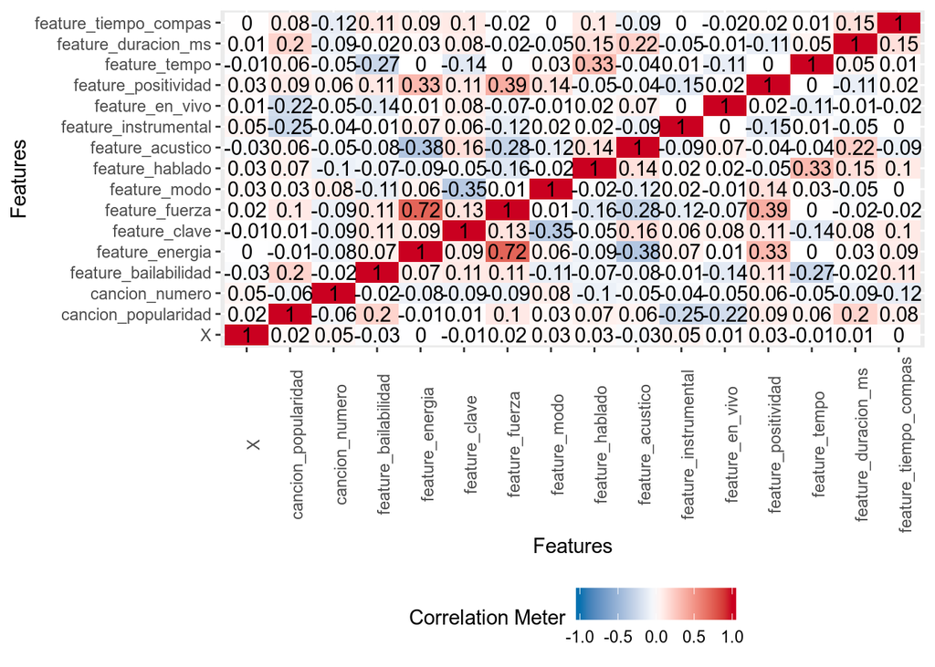

```r
plot_correlation(distinct(dataset), type="c")
```

Podemos ver que las features que más se correlacionan son la fuerza y energia, por lo que en general mientras mayor fuerza tiene una canción, mayor va a ser su energía. Luego la feature acustico se correlaciona inversamente con la energía, por lo que a mayor energía menor es su acustica.

### Relacion entre features

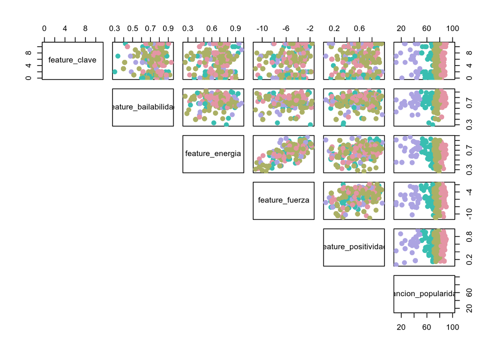

```r
bins_pop <- .bincode(dataset$cancion_popularidad , c(0,50,70,80,90,100), TRUE)

#paises <- dataset$pais_nombre
paises_col <- rev(rainbow_hcl(4))[as.numeric(bins_pop)]

# Plot
pairs(dataset %>% select(feature_clave, feature_bailabilidad, feature_energia, feature_fuerza, feature_positividad,
                          cancion_popularidad ),
      col = paises_col,
      lower.panel = NULL,
      cex.labels=1, pch=19, cex = 1.2)
```

El objetivo de este gráfico es visualizar la relacion entre la popularidad, coloreada con distintos colores, con las distintas features. Lo que se puede observar es que la popularidad es independiente de las demás, ya que muestra valores dispersos.

### cantidad de canciones repetidas por pais

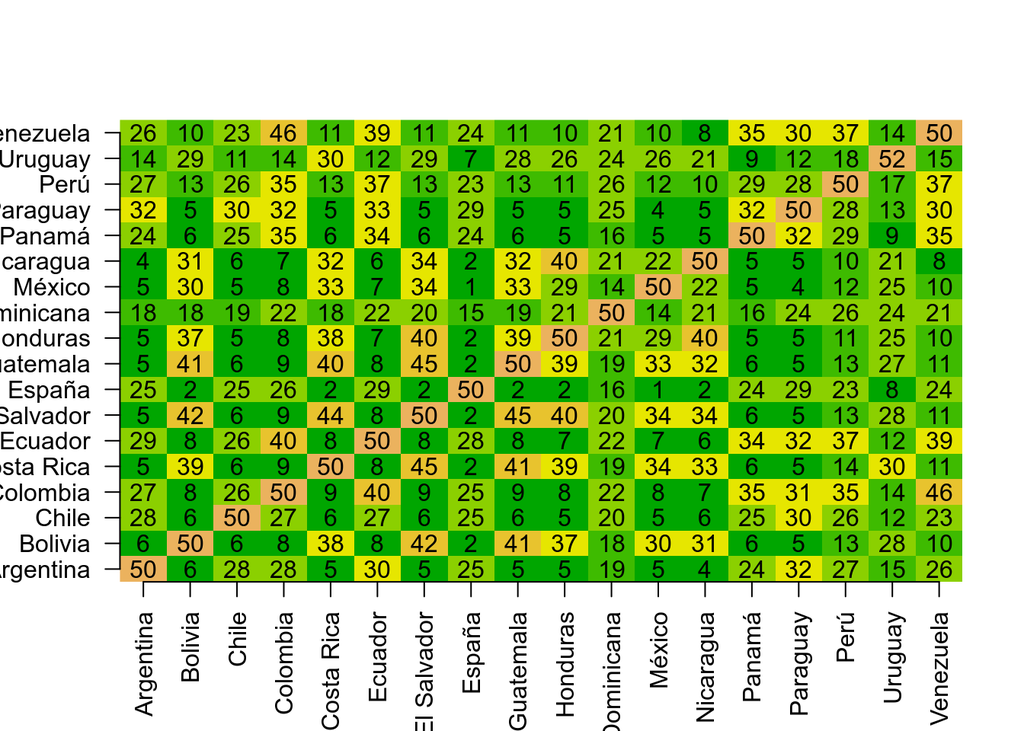

```r
canciones <- levels(dataset[,2])
paises <- levels(dataset[,8])
repeated <- matrix(ncol = length(paises), nrow = length(paises))
rownames(repeated) <- paises
colnames(repeated) <- paises

for(p in 1:length(paises)){
  for(p2 in 1:length(paises)){
    counter <- 0
    for(i in dataset[dataset[,8]==paises[p],2]){
      if(i %in%  dataset[dataset[,8]==paises[p2],2]){
        counter <- counter + 1
      }
    }
    repeated[p,p2] <- counter
  }
}

image(1:ncol(repeated), 1:nrow(repeated), t(repeated), col = terrain.colors(9), axes = FALSE, xlab = "", ylab = "",
      breaks= c(0,9,19,29,39,49,59,79,89,100))
  axis(1, 1:ncol(repeated), colnames(repeated), las = 2 )
  axis(2, 1:nrow(repeated), rownames(repeated), las = 1)
  for (x in 1:ncol(repeated))
    for (y in 1:nrow(repeated))
      text(x, y, repeated[y,x])
```

En este gráfico podemos observar y comparar los gustos musicales entre países, se muestran la cantidad de canciones en común entre los distintos países. Podemos ver que Venezuela y Colombia poseen muchas canciones en común, y en general los paises limítrofes, o con culturas similares, comparten una mayor cantidad de canciones en su top 50.

### Histogramas

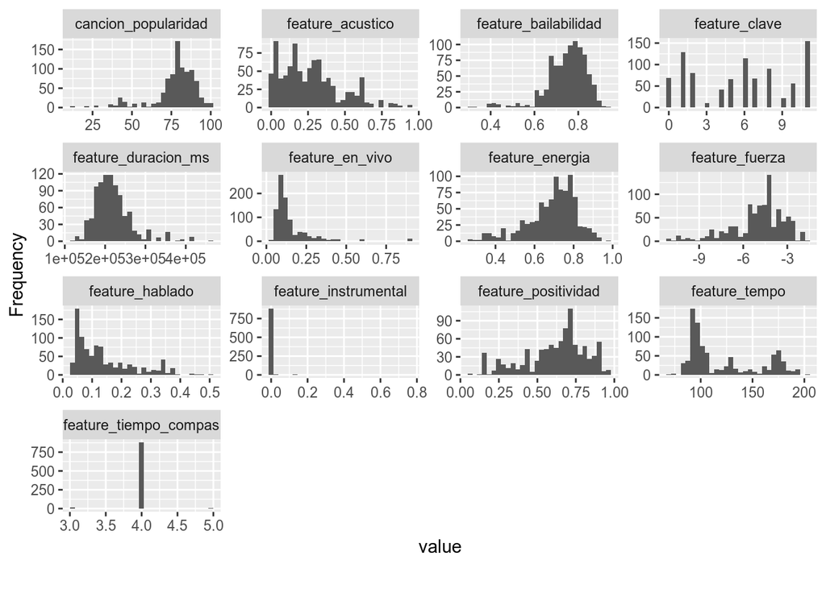

```r
data <- dataset %>% t
plot_histogram(dataset[-c(1,7)]) # 1 y 7 son el indice y numero de canción por lo que no los tenemos en cuenta
```

### Gráfico de densidad

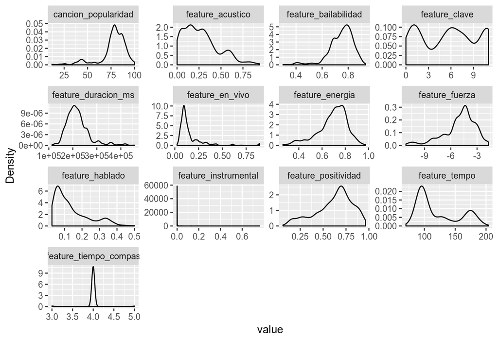

```r
plot_density(dataset[-c(1,7)])
```